# Steamboat Island Mussel Pilot Report

Environmental Monitoring and Management Application (EMMA) · Science and Restoration Integration

The Steamboat Island feasibility report anticipates an additional mussel-habitat benefit from stone protection. This pilot examines the scientific basis for that expectation and the evidence needed to evaluate it locally. **The current record supports an anticipated benefit, not a demonstrated post-construction mussel outcome.**

## The Steamboat Island pilot

**Pilot question — Analyst formulation for review**

Could restoration features improve mussel persistence through hydraulic and substrate changes, and how would we evaluate that expectation at Steamboat Island?

| Item | Understanding |
| --- | --- |
| Restoration intent | ancillary anticipated benefit; not formal project objective |
| Project stage in the supplied record | Construction ongoing; baseline/construction monitoring reported by the user. This report does not update construction status. |
| Monitoring commitment | Dedicated post-construction mussel surveys: not committed by this feasibility plan |

Mussel habitat is an **ancillary benefit**, separate from the project’s formal objectives and performance criteria. The absence of post-construction performance data at this stage is not evidence of failure. The absence of a dedicated mussel-survey commitment is a separate planning consideration.

## Restoration intent and the expected response

The recommended plan describes potential additional fish/mussel habitat associated with stone protection (feasibility report VI-1, PDF p. 133). Table X-3 footnote 8 (X-4, PDF p. 169) does not commit dedicated post-construction mussel surveys. The final feature design, installation identity and local mussel response have not been reconciled in this pilot.

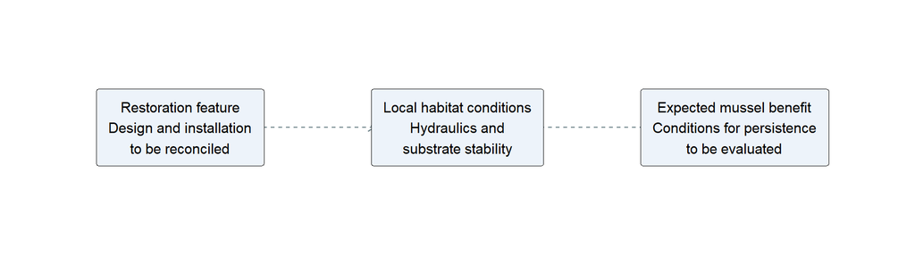

**How to read the diagram:** the arrows identify relationships to investigate. They do not establish that a feature has produced the expected conditions or that mussels have responded. Persistence, survival, recruitment and habitat occupancy are related but distinct possible responses; the pilot has not selected a local endpoint or numerical success threshold.

## What the science contributes

The following extracts help explain why substrate and hydraulic conditions warrant investigation. Most are based on abstracts; they retain the source studies’ inference limits and have not received SME review.

| Reference | Scientific contribution | Limit on use at Steamboat Island |
| --- | --- | --- |
| SC-02 / MS-02 | Low-flow transport and high-flow hydraulic refuge are proposed explanations for hydraulic associations with mussel density. | Specific retrospective reach/flow context; no universal numerical design threshold extracted. |
| SC-03 / MS-03 | Authors report species/time variation and higher core-habitat survival; growth differed by species and age, without a significant core/periphery difference. Substrate stability is an author interpreta… | Do not infer that a Steamboat intervention caused survival changes. |
| SC-05 / MS-04 | Recruitment strength is associated with discharge metrics, with different selected predictors for life-history groups. | Species/life-history and retrospective cohort scope retained; no transferred coefficients or universal threshold. |

The hydraulic interpretation and habitat-dependent survival findings informed the following **proposed local hypothesis**, SC-08. It is an assistant formulation for review, not a verbatim author statement or a hypothesis known to have been adopted by the project’s designers.

**SC-08 — proposed local hypothesis**

A proposed restoration intervention maintaining suitable substrate stability across relevant flows may improve local conditions for mussel persistence.

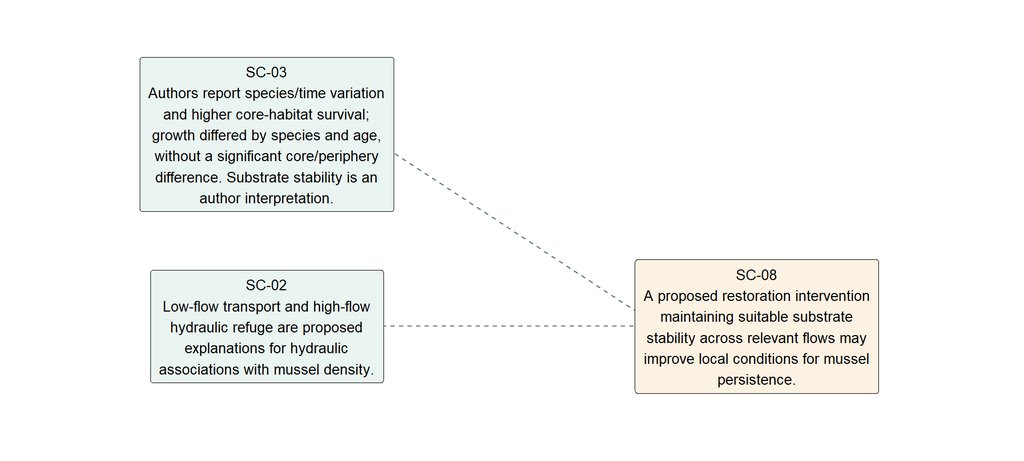

These links explain the hypothesis’s origin. Applying the research to Steamboat Island still requires review of the study locations, species, flow regimes, methods and relevance to the local intervention. No sampled publication is asserted here to have evaluated Steamboat Island.

### Tracing one study: what survival and growth tell us

MS-03 (Newton et al. 2020) can now be traced into its public data release. The inspected sources distinguish the comparison, repeated observations, reported findings and local interpretation. Full-text model details remain unverified.

| object | record | locator |
| --- | --- | --- |
| Study context | West Newton Chute, Pool 5; tagging in 2012 and annual recoveries in 2013–2016. This is not Steamboat Island. | Data-release description; FGDC /metadata/dataqual/lineage/procstep/procdesc |
| Comparison design | Historical density defined core/periphery polygons; five 5 × 5 m plots per polygon. Tagged mussels were allocated among plots. Density habitats were not randomly imposed restoration treatments. | Data-release description, IDW quartiles and plot allocation |
| Sampling and observations | PIT identity, recovery, live/dead status and shell length were recorded repeatedly. Plot visits retain dates, depth and search effort. | FGDC eainfo/detailed attribute definitions; tracking data.csv and plot data.csv headers |
| Finding — survival | Authors report higher survival in core habitat and variation among species and years. | Publication abstract §3 |
| Finding — growth | Authors report species and age differences, without a significant core/periphery growth difference. | Publication abstract §4 |

**Implication for this pilot:** survival and growth are distinct responses. A habitat contrast in one does not establish the same contrast in the other. This study informs a local question; it does not establish a Steamboat restoration effect.

**Source reconciliation needed:** the narrative reports 578 tagged mussels; the tracking file contains 569 individual IDs, and the 2012 plot placement counts sum to 576. These totals have been preserved separately. Their differences are unresolved, and no new vital rates were calculated.

## What would let us evaluate the benefit here

| Part of the evidence chain | Current pilot record | Next useful work |
| --- | --- | --- |
| Restoration feature and location | Ancillary intent is documented; actual feature identity/design/installation is unresolved | Review final design and available as-built/GIS records; identify the feature and habitat area to evaluate |
| Habitat conditions and mechanism | Hydraulic/substrate reasoning comes from research; local change has not been demonstrated | Review local flow and substrate evidence across relevant conditions and compare it with the studies’ scope |
| Mussel population and response | Baseline/construction monitoring is reported, but mussel-specific observations and analyses are not assembled in this pilot | Identify species, existing surveys, sampling periods and measured responses; assess suitability for the question |
| Study design and inference | No local comparison design or demonstrated post-construction effect is established | Determine an appropriate comparison, timing, analysis and treatment of alternative explanations before drawing conclusions |

The feasibility report identifies the annual interagency Cordova Mussel Blitz as a possible external data opportunity. Availability and suitability need checking; it is not a guaranteed dataset or a dedicated project task.

## Next steps for this pilot

1. **Confirm the local restoration connection.** Identify the relevant feature, location, design intent and available construction evidence.
2. **Resolve the scientific transfer questions.** The MS-03 source-to-data instance is now available below. Reconcile its cohort counts, verify full-paper analysis and substrate metrics, and review applicability alongside MS-02.
3. **Assess the evidence that could answer the question.** Inventory local mussel/habitat data and identify the smallest useful analysis or study-design increment, including any missing observations and review responsibilities.

The next deliverable should be one inspectable chain from restoration expectation through scientific reasoning to available observations and remaining needs. It should help partners decide whether existing data can address the expectation or whether additional work is justified. This report creates no new monitoring commitment.

## Background — workshop research priorities

The workshop workbook records a broader question, **WQ-39**: How do substrate composition, heterogeneity, and stability influence mussels, other benthic invertebrate, and spawning habitat for fish in channel environments? Its recorded Lower Impounded priority rank is **16** (1 = highest priority). This supplies program context for the mussel pilot; the proposed link to SC-08 does not establish equivalence or a completed scientific test.

Steamboat Island is listed in the Lower Impounded sheet, with no question marks recorded in its column. A blank association is not evidence of absent learning value. Full priority information is retained below as background.

## Supporting record

**MS-03 scientific instance: full evidence chain and unresolved checks**

assistant extraction and applicability proposal; not SME-reviewed . USGS publication abstract; ScienceBase release description, FGDC metadata and both CSVs. Publisher full text inaccessible; analysis not reproduced.

Publication abstract · ScienceBase data release 10.5066/P9HRXPJQ

| object | record | locator | basis |
| --- | --- | --- | --- |
| Research purpose | Compare survival and growth among species, years and mussel-density patches. | Data-release description, objectives | Source paraphrase |
| Study context | West Newton Chute, Pool 5; tagging in 2012 and annual recoveries in 2013–2016. This is not Steamboat Island. | Data-release description; FGDC /metadata/dataqual/lineage/procstep/procdesc | Source paraphrase |
| Comparison design | Historical density defined core/periphery polygons; five 5 × 5 m plots per polygon. Tagged mussels were allocated among plots. Density habitats were not randomly imposed restoration treatments. | Data-release description, IDW quartiles and plot allocation | Source description plus analyst inference limit |
| Sampling and observations | PIT identity, recovery, live/dead status and shell length were recorded repeatedly. Plot visits retain dates, depth and search effort. | FGDC eainfo/detailed attribute definitions; tracking data.csv and plot data.csv headers | Inspected metadata and file structure |
| Dataset | Two inspected CSVs: 569 individual records and 100 plot-visit rows. These are file counts, not independently estimated survival rates. | CSV inventory, review-mussel-vital-rates.R | Reproducible file inspection |
| Analysis | Published survival and growth comparisons are identified, but fitted models, detection assumptions, exclusions and uncertainty estimates remain unverified. The inspected release lists metadata and two… | Publication abstract §§3–4; ScienceBase JSON files list | Source scope and explicit gap |
| Finding — survival | Authors report higher survival in core habitat and variation among species and years. | Publication abstract §3 | Reported finding; not independently reproduced |
| Finding — growth | Authors report species and age differences, without a significant core/periphery growth difference. | Publication abstract §4 | Reported finding; not independently reproduced |
| Interpretation | Authors infer the importance of substrate stability; their core/periphery source–sink explanation requires further recruitment-source testing. | Publication abstract §§3,5; SC-04 | Author interpretation and unconfirmed hypothesis |
| Local applicability | SC-03 informs formulation of SC-08. Compare local substrate dynamics, flows, species and sampling design before transferring the interpretation. No Steamboat treatment effect or numerical criterion fo… | SC-03 → SC-08; Steamboat feasibility VI-1 and X-4 footnote 8 | Assistant proposal for partner review |

Publication/release narrative says 578 tagged mussels; the inspected tracking file has 569 unique individual IDs and the plot file sums to 576 placed in 2012. Reconcile cohort accounting before analysis; do not silently replace any source total.

CSV taxon label Quadrula pustulosa differs from Cyclonaias pustulosa in the abstract. Preserve both original labels; obtain an explicit taxonomic mapping before joining.

Not located, missing ‘.’, recorded dead and carried-forward status must remain distinguishable. A missing recovery is not automatically mortality.

The abstract includes an apparently inconsistent directional statement about survival versus substrate stability. Resolve the metric and sign in full methods/results before encoding a quantitative relationship.

No local restoration feature, adopted hypothesis, post-construction observation or empirical support edge has been established by this extraction.

| Source | MD5 | URL |
| --- | --- | --- |
| Estimation of vital rates to assess the relative health of mussel resources in the Upper Mississippi River System.xml | 4203263a7e1fcb2604052c2aa2ab75af | https://www.sciencebase.gov/catalog/file/get/5d583085e4b01d82ce8ec16e?f=__disk__ea%2F3a%2Fee%2Fea3aee7d4ffbcfb4a1b71146bec8fc4d941b095d |
| plot data.csv | c0b76177857aa80baec345803f986566 | https://www.sciencebase.gov/catalog/file/get/5d583085e4b01d82ce8ec16e?f=__disk__82%2Fad%2F06%2F82ad061a519398e13a692a338c8398f906fd3a73 |
| tracking data.csv | fc92616553daab457d843e2ef8fb41fd | https://www.sciencebase.gov/catalog/file/get/5d583085e4b01d82ce8ec16e?f=__disk__bb%2F51%2F16%2Fbb5116ef120fc1957357867377b60f03e176fee9 |

**Scientific publications and source reading depth**

| id | doi | source_url | reading_depth |
| --- | --- | --- | --- |
| MS-01 | 10.1007/s10750-007-9167-1 | https://pubs.usgs.gov/publication/70033362 | USGS abstract; Zotero metadata |
| MS-02 | 10.1007/s10750-008-9423-z | https://www.usgs.gov/publications/use-complex-hydraulic-variables-predict-distribution-and-density-unionids-a-side | USGS abstract; Zotero metadata |
| MS-03 | 10.1111/fwb.13575 | https://pubs.usgs.gov/publication/70215652 | USGS abstract; companion ScienceBase description, FGDC metadata and two CSVs inspected 2026-10-21 (mussel-vital-rates-instance.json). Full article methods/results inaccessible. |
| MS-04 | 10.1002/aqc.2590 | https://pubs.usgs.gov/publication/70159856 | USGS abstract; collection title observed; item key not captured |
| MS-05 | 10.31931/fmbc-d-21-00004 | https://molluskconservation.org/PUBLICATIONS/FMBC/EARLY%20VIEW/FMBC_Vol25_Newton_EarlyView.pdf | Selected full-text sections; collection title observed; item key not captured |
| MS-06 | 10.5751/ES-10014-230206 | https://www.usgs.gov/publications/developing-a-shared-understanding-upper-mississippi-river-foundation-ecological | USGS summary; Zotero metadata |

MS-01 primary source

MS-02 primary source

MS-03 primary source

MS-04 primary source

MS-05 primary source

MS-06 primary source

| Item | Record |
| --- | --- |
| Research outputs in sample | 6 |
| Source-based assertion records | 7 |
| Review status | initial purposive sample; source depth labelled; user/SME review pending |

These are worksheet counts, not independent-study counts or confidence scores.

**Full scientific assertion locators and review states**

| id | source_id | kind | paraphrase | source_locator | limit | extraction_status |
| --- | --- | --- | --- | --- | --- | --- |
| SC-01 | MS-01 | reported_analysis_and_finding | Retrospective statistical and geospatial analyses connect physical/hydraulic predictors to mussel distribution. | Abstract | Exploratory associations and predictions; not evidence of an experimental restoration effect. | assistant source-based extraction; not SME-reviewed |
| SC-02 | MS-02 | author_interpretation | Low-flow transport and high-flow hydraulic refuge are proposed explanations for hydraulic associations with mussel density. | Abstract, final interpretation | Specific retrospective reach/flow context; no universal numerical design threshold extracted. | assistant source-based extraction; not SME-reviewed |
| SC-03 | MS-03 | reported_finding | Authors report species/time variation and higher core-habitat survival; growth differed by species and age, without a significant core/periphery difference. Substrate stability is an author interpreta… | USGS publication abstract sections 3-5; expanded instance: mussel-vital-rates-instance.json | Do not infer that a Steamboat intervention caused survival changes. | assistant source-based extraction; not SME-reviewed |
| SC-04 | MS-03 | author_hypothesis_requiring_test | Core-to-periphery source-sink dynamics are proposed, with further recruitment-source studies needed. | Abstract, habitat-specific survival interpretation | Proposed explanation is not a confirmed population mechanism. | assistant source-based extraction; not SME-reviewed |
| SC-05 | MS-04 | reported_analysis_and_finding | Recruitment strength is associated with discharge metrics, with different selected predictors for life-history groups. | Abstract points 3-6 | Species/life-history and retrospective cohort scope retained; no transferred coefficients or universal threshold. | assistant source-based extraction; not SME-reviewed |
| SC-06 | MS-05 | reported_method_and_finding | Literature and expert-derived biological parameter estimates enter HEA scenarios; sensitivity analysis exposes uncertainty in restoration-scaling outputs. | Early-view PDF pp3-4 Parameterization; p6 Sensitivity Analysis; p8 Data Needed | Selected text sections only; no table-cell values transcribed and no claim HEA was used for Steamboat. | assistant source-based extraction; not SME-reviewed |
| SC-07 | MS-06 | conceptual_framework | A shared UMRS model distinguishes connected channel, off-channel and floodplain systems and controlling variables across scales. | USGS summary paragraphs 1-4 | System context; not a mussel-specific restoration-effect study. | assistant source-based extraction; not SME-reviewed |
| SC-08 | Not recorded | assistant_formulated_local_design_hypothesis | A proposed restoration intervention maintaining suitable substrate stability across relevant flows may improve local conditions for mussel persistence. | Not recorded | Not a verbatim author hypothesis or demonstrated treatment effect. Requires applicability review and local design/observation evidence. | proposal for review |

| from | to | relationship |
| --- | --- | --- |
| SC-02 | SC-08 | informs formulation |
| SC-03 | SC-08 | informs formulation |

**Conceptual entities and formal project objectives**

The entities are candidate distinctions for data-model development. They are not approved tables or ontology classes. Formal project objectives remain separate from the ancillary mussel benefit.

| Entity | Meaning |
| --- | --- |
| Source and passage | Publication/version and precise evidence locator |
| Study and execution | Investigation distinct from its outputs |
| Question and hypothesis | Explicit proposition distinct from reconstructed expectation |
| Study and sampling design | Method and comparison supporting the inference |
| Population and habitat context | Species, life stage, reach, substrate, flow and period |
| Property, observation and result | Measured property, event and returned value |
| Dataset, analysis and model run | Inputs and methods; observed data distinct from modeled output |
| Parameter and assumption | Data-derived estimate distinct from expert judgment |
| Finding and conclusion | Result distinct from explanatory interpretation |
| Evidence assessment | Scope and rationale of support, challenge or uncertainty |
| Design rationale and expected response | Why an intervention may produce a benefit |
| Applicability and knowledge gap | Review of transfer to another site and missing evidence |
| Priority-defining artifact and assessment | Workshop source, question, reach-specific rank and assessment edition; priority is not evidence strength |
| Pilot relevance assessment | Explicit proposed link from a workshop question to the pilot; not proof of a study or designer adoption |

| id | name | source_text_normalized | detailed_criterion_pdf_pages |
| --- | --- | --- | --- |
| SI-O1 | Floodplain forest diversity | Enhance and restore areal coverage and diversity of forest stands and habitat and increase diversity of bottomland hardwood forest, as measured in forested acres suitable to support hard-mast species … | 701; 702 |
| SI-O2 | Aquatic diversity | Increase year-round aquatic habitat diversity, as measured by acres and limnophilic native fish use of overwintering habitat, as this habitat is the most limiting of seasonal habitats. | 702; 703 |
| SI-O3 | Island restoration and protection | Restore 50% of island acreage and topography lost since the 1950s and protect from erosion within the Project area, as measured by acres. | 703 |
| SI-O4 | Backwater protection and interior wetland enhancement | Protect existing backwater habitat from sediment deposition and enhance backwater and interior wetland areas, as measured by acres of backwater and survivability of scrub-shrub/pollinator habitat. | 703; 704; 705 |

| Item | Record |
| --- | --- |
| project | Steamboat Island HREP |
| benefit | anticipated ancillary mussel habitat benefit |
| restoration_evidence | steamboat-island-objectives-criteria.json:mussel_benefit |
| design_hypothesis | SC-08 |
| relationship_status | proposed applicability link, not evidence of adoption by project designers |
| installed_feature_identity | Not recorded |
| demonstrated_postconstruction_mussel_effect | Not recorded |
| dedicated_postconstruction_mussel_survey_commitment | not in reviewed feasibility plan |

The existing conceptual chain is HREP → Project Objective → Performance Criterion → Monitoring Task → Observation. Production observation storage and cross-system identities remain unverified. Existing USACE document, provenance, temporal, spatial and SOSA patterns provide the organizational baseline.

**Full workshop learning agenda and priority-source detail**

| Item | Record |
| --- | --- |
| Artifact | research_question_ranks.xlsx |
| Purpose | Records workshop research priorities by river reach |
| Source location | Ranked by Reach!A1:G51 |
| Questions | 49 |
| Rank definition | Rank average of weighted agency averages (1=highest priority, 49=lowest priority) |
| Identifier scope | WQ IDs are review-local worksheet locators, not program or production IDs. |

Assistant-proposed relevance links for pilot review; not SME-reviewed . Mussel research pilot; links do not establish designer adoption, a completed test or equivalence to SC-08.

Workshop dates, raw agency ratings, weighting rules and meaning of n are not supplied.

An x is a recorded association with no supplied legend or evidence of a completed hypothesis test.

Blank project cells are unrecorded associations, not documented absence or lack of suitability.

Four embedded project/feature inventory images are historical reference material; their dates and current status are unverified.

| Question | Role | Reason for proposed relevance |
| --- | --- | --- |
| WQ-39 | Primary priority question | The workshop asks how substrate composition, heterogeneity and stability influence mussels and other taxa. SC-08 proposes a narrower local substrate-stability/persistence hypothesis within this topic. |
| WQ-05 | Related restoration-mechanism question | This question concerns interventions that shape channel substrates. It supplies restoration context for the pilot; a specific feature-to-response link still needs evidence. |
| WQ-40 | Related connectivity question | Mussel responses to side-channel connectivity may matter to local applicability. Connectivity effects are broader than, and not equivalent to, SC-08. |
| WQ-37 | Additional adverse-response question | The workshop also asks about adverse fish/mussel effects of water-level management. This is a separate question for consideration, not a result established by the current science sample. |

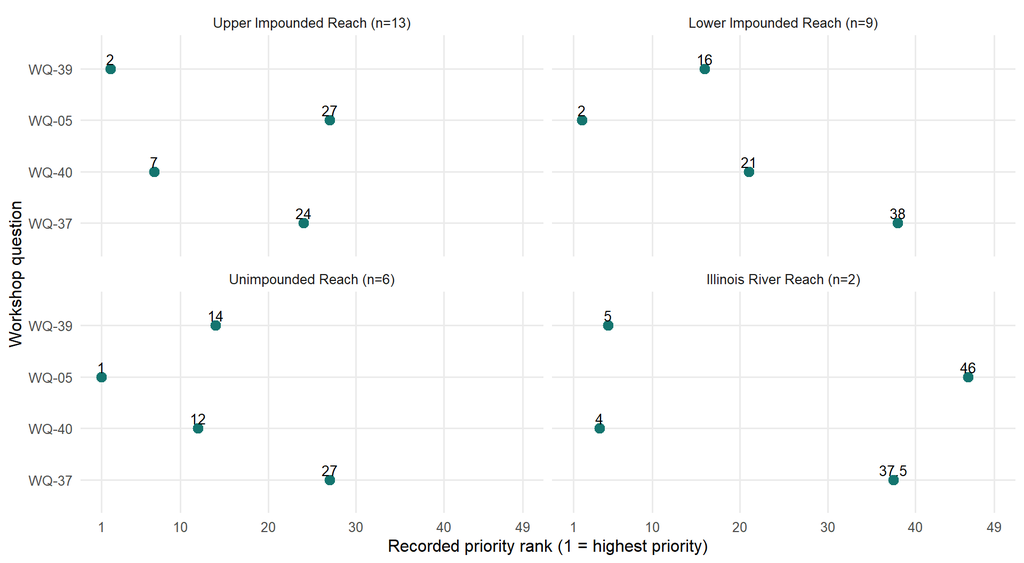

| Question | Original wording | Workshop restoration goal | Workshop restoration objective |
| --- | --- | --- | --- |
| WQ-01 | What physical and ecological processes influence the rate of large wood accumulation in backwaters, and how does large wood affect sediment dynamics? | Restore and sustain hydraulic, geomorphic, and sediment transport functions that create and maintain a dynamic and diverse river-floodplain ecosystem | Enhance hydrologic and geomorphic conditions that sustain depth diversity and reduce sediment deposition in backwaters |
| WQ-02 | Which environmental and geomorphic factors (e.g., hydraulic connectivity, flow velocity, sediment supply, vegetation, placement relative to main channel) explain why some backwaters retain depth while… | Restore and sustain hydraulic, geomorphic, and sediment transport functions that create and maintain a dynamic and diverse river-floodplain ecosystem | Enhance hydrologic and geomorphic conditions that sustain depth diversity and reduce sediment deposition in backwaters |
| WQ-03 | What combinations of restoration techniques and morphometric characteristics (e.g., mean depth, depth diversity, maximum depth, side slopes, substrate diversity, protective berms) most effectively red… | Restore and sustain hydraulic, geomorphic, and sediment transport functions that create and maintain a dynamic and diverse river-floodplain ecosystem | Enhance hydrologic and geomorphic conditions that sustain depth diversity and reduce sediment deposition in backwaters |
| WQ-04 | How do variations in water residence time and channel–backwater flow exchange influence sediment and nutrient capture and processing (and occurrence of cyanobacteria)? | Restore and sustain hydraulic, geomorphic, and sediment transport functions that create and maintain a dynamic and diverse river-floodplain ecosystem | Enhance hydrologic and geomorphic conditions that sustain depth diversity and reduce sediment deposition in backwaters |
| WQ-05 | How can restoration techniques (for example, adjust side channel connectivity, shoreline protection) be enhanced to shape beneficial substrate conditions in channel environments? | Restore and sustain hydraulic, geomorphic, and sediment transport functions that create and maintain a dynamic and diverse river-floodplain ecosystem | Improve flow diversity and substrate conditions in channels, sloughs, and channel borders |
| WQ-06 | What restoration techniques most effectively reduce sediment deposition in side channels? | Restore and sustain hydraulic, geomorphic, and sediment transport functions that create and maintain a dynamic and diverse river-floodplain ecosystem | Improve flow diversity and substrate conditions in channels, sloughs, and channel borders |
| WQ-07 | How can understanding island development inform where to promote island formation, and which techniques (for example, seed islands or wood pilings) are most effective? | Restore and sustain hydraulic, geomorphic, and sediment transport functions that create and maintain a dynamic and diverse river-floodplain ecosystem | Manage and restore island soils, vegetation, and geomorphic processes to sustain island distribution and abundance while accommodating ongoing geomorphic dynamics |
| WQ-08 | In what ways can protective features be enhanced to provide greater ecological benefits (for example, placement of slab rock, large wood, woody bundles) and how do ecological responses compare to more… | Restore and sustain hydraulic, geomorphic, and sediment transport functions that create and maintain a dynamic and diverse river-floodplain ecosystem | Manage and restore island soils, vegetation, and geomorphic processes to sustain island distribution and abundance while accommodating ongoing geomorphic dynamics |
| WQ-09 | How do differences in dredge material source and resulting soil conditions, together with designed island elevation, shape vegetation outcomes and long-term island development? | Restore and sustain hydraulic, geomorphic, and sediment transport functions that create and maintain a dynamic and diverse river-floodplain ecosystem | Manage and restore island soils, vegetation, and geomorphic processes to sustain island distribution and abundance while accommodating ongoing geomorphic dynamics |
| WQ-10 | What are the rates of island erosion, accretion, and establishment of early successional forest across the system? | Restore and sustain hydraulic, geomorphic, and sediment transport functions that create and maintain a dynamic and diverse river-floodplain ecosystem | Manage and restore island soils, vegetation, and geomorphic processes to sustain island distribution and abundance while accommodating ongoing geomorphic dynamics |
| WQ-11 | How does water level management affect species diversity and areal extent of plant growth forms? | Reestablish and maintain the physical and water-quality conditions that support resilient aquatic vegetation assemblages | Enhance topobathymetric complexity, water clarity, and water levels to promote aquatic vegetation |
| WQ-12 | How does aquatic vegetation composition, density, and seasonal phenology influence seasonal habitat conditions for target taxa? | Reestablish and maintain the physical and water-quality conditions that support resilient aquatic vegetation assemblages | Enhance topobathymetric complexity, water clarity, and water levels to promote aquatic vegetation |
| WQ-13 | How can the effectiveness of restoring aquatic vegetation be sustained in areas with heavy herbivore pressure (e.g., grass carp, red-eared slider), and what management strategies are most effective? | Reestablish and maintain the physical and water-quality conditions that support resilient aquatic vegetation assemblages | Enhance topobathymetric complexity, water clarity, and water levels to promote aquatic vegetation |
| WQ-14 | Can aquatic vegetation density/biomass affect nutrient cycling and improve water quality? | Reestablish and maintain the physical and water-quality conditions that support resilient aquatic vegetation assemblages | Enhance topobathymetric complexity, water clarity, and water levels to promote aquatic vegetation |
| WQ-15 | How do biophysical feedbacks and sediment trapping vary by composition of aquatic vegetation and density/biomass? | Reestablish and maintain the physical and water-quality conditions that support resilient aquatic vegetation assemblages | Enhance topobathymetric complexity, water clarity, and water levels to promote aquatic vegetation |
| WQ-16 | How does feature height (sub-surface, at-surface, and above-surface) influence wave energy, flow dynamics, wind shadows, and ambient turbidity across varying water levels; and how do these conditions … | Reestablish and maintain the physical and water-quality conditions that support resilient aquatic vegetation assemblages | Enhance topobathymetric complexity, water clarity, and water levels to promote aquatic vegetation |
| WQ-17 | How does proximity to existing forest influence revegetation of restoration sites? | Restore ecosystem functions that drive succession, structural diversity, and long-term resilience of floodplain vegetation | Reduce forest fragmentation and promote natural forest regeneration |
| WQ-18 | How do regeneration dynamics of individual species influence forest succession within a given stand? | Restore ecosystem functions that drive succession, structural diversity, and long-term resilience of floodplain vegetation | Reduce forest fragmentation and promote natural forest regeneration |
| WQ-19 | How does sediment composition and compaction affect the success of burying non‑native invasive plants (such as reed canarygrass and hops) to improve tree survival? | Restore ecosystem functions that drive succession, structural diversity, and long-term resilience of floodplain vegetation | Reduce forest fragmentation and promote natural forest regeneration |
| WQ-20 | How do site conditions and management actions—such as soil composition, compaction, inundation, elevation, invasive species pressure, light availability, site preparation, post‑planting maintenance, p… | Restore ecosystem functions that drive succession, structural diversity, and long-term resilience of floodplain vegetation | Reduce forest fragmentation and promote natural forest regeneration |
| WQ-21 | What is the role of groundwater relative to flood inundation on forest dynamics? | Restore ecosystem functions that drive succession, structural diversity, and long-term resilience of floodplain vegetation | Reduce flood stress on trees and understand ecological responses to floodplain hydrology |
| WQ-22 | How does floodplain vegetation respond to ridge and swale topography? | Restore ecosystem functions that drive succession, structural diversity, and long-term resilience of floodplain vegetation | Reduce flood stress on trees and understand ecological responses to floodplain hydrology |
| WQ-23 | How does sediment composition and compaction influence the outcomes of thin layer placement on existing forest? | Restore ecosystem functions that drive succession, structural diversity, and long-term resilience of floodplain vegetation | Reduce flood stress on trees and understand ecological responses to floodplain hydrology |
| WQ-24 | What is the importance of soil conditions relative to other factors on floodplain vegetation? | Restore ecosystem functions that drive succession, structural diversity, and long-term resilience of floodplain vegetation | Enhance forest structural complexity |
| WQ-25 | Can existing datasets be used to develop floodplain forest stocking charts or a site suitability index that guide forest treatments? | Restore ecosystem functions that drive succession, structural diversity, and long-term resilience of floodplain vegetation | Enhance forest structural complexity |
| WQ-26 | What are the effects of prescribed fire on forest health and tree growth in floodplains? | Restore ecosystem functions that drive succession, structural diversity, and long-term resilience of floodplain vegetation | Enhance forest structural complexity |
| WQ-27 | What hard mast species are best suited for planting/ or promotion in the floodplain and what conditions are required to support these species? | Restore ecosystem functions that drive succession, structural diversity, and long-term resilience of floodplain vegetation | Enhance forest structural complexity |
| WQ-28 | What are the effects of forest stand improvements on forest health and tree growth? | Restore ecosystem functions that drive succession, structural diversity, and long-term resilience of floodplain vegetation | Enhance forest structural complexity |
| WQ-29 | How does pollinator use of island floral resources compare with ‘mainland’ areas, including those that become dewatered seasonally or during low-water periods? | Restore ecosystem functions that drive succession, structural diversity, and long-term resilience of floodplain vegetation | Increase diversity and establishment of native herbaceous vegetation while minimizing invasive species expansion |
| WQ-30 | What are the roles of elevation, inundation, and light conditions on non-native, invasive herbaceous species (e.g., reed canarygrass, hops)? | Restore ecosystem functions that drive succession, structural diversity, and long-term resilience of floodplain vegetation | Increase diversity and establishment of native herbaceous vegetation while minimizing invasive species expansion |
| WQ-31 | What factors influence the success of native herbaceous plant mixes, and how do these mixes—including the use of cover crops—affect the recruitment and natural regeneration of floodplain forest specie… | Restore ecosystem functions that drive succession, structural diversity, and long-term resilience of floodplain vegetation | Increase diversity and establishment of native herbaceous vegetation while minimizing invasive species expansion |
| WQ-32 | How do variations in floodplain inundation (timing and duration) influence the diversity, abundance, and reproductive success of amphibian and reptile communities? | Support and sustain diverse fish and wildlife communities by restoring habitat conditions and ecological functions | Improve understanding of habitat functions and ecological conditions that support fish and wildlife |
| WQ-33 | How do land‑bird communities respond to floodplain forest rehabilitation (e.g., stand improvements) and proximity to existing forest? | Support and sustain diverse fish and wildlife communities by restoring habitat conditions and ecological functions | Improve understanding of habitat functions and ecological conditions that support fish and wildlife |
| WQ-34 | What are the habitat conditions required by secretive marsh birds, shorebirds, waterfowl, and wading birds – particularly species of conservation concern? | Support and sustain diverse fish and wildlife communities by restoring habitat conditions and ecological functions | Improve understanding of habitat functions and ecological conditions that support fish and wildlife |
| WQ-35 | How do bat communities respond to enhancements in forest structural complexity? | Support and sustain diverse fish and wildlife communities by restoring habitat conditions and ecological functions | Improve understanding of habitat functions and ecological conditions that support fish and wildlife |
| WQ-36 | What is the pollinator response to drawdowns (i.e., moist soil units)? | Support and sustain diverse fish and wildlife communities by restoring habitat conditions and ecological functions | Improve understanding of habitat functions and ecological conditions that support fish and wildlife |
| WQ-37 | Are there negative effects of water level management/drawdowns on fish or mussels? | Support and sustain diverse fish and wildlife communities by restoring habitat conditions and ecological functions | Improve understanding of habitat functions and ecological conditions that support fish and wildlife |
| WQ-38 | How do structure height, proximity to shorelines, water-body size, and aquatic vegetation composition influence waterfowl (canvasback), wading birds, and fisheries habitat use? | Support and sustain diverse fish and wildlife communities by restoring habitat conditions and ecological functions | Improve understanding of habitat functions and ecological conditions that support fish and wildlife |
| WQ-39 | How do substrate composition, heterogeneity, and stability influence mussels, other benthic invertebrate, and spawning habitat for fish in channel environments? | Support and sustain diverse fish and wildlife communities by restoring habitat conditions and ecological functions | Improve understanding of habitat functions and ecological conditions that support fish and wildlife |
| WQ-40 | How do fish (resident and migratory species), mussels, and macroinvertebrates respond to changes in side-channel connectivity across different spatial scales? | Support and sustain diverse fish and wildlife communities by restoring habitat conditions and ecological functions | Improve understanding of habitat functions and ecological conditions that support fish and wildlife |
| WQ-41 | How do large wood features influence hydraulic and substrate diversity and the composition of macroinvertebrates and fish assemblages? | Support and sustain diverse fish and wildlife communities by restoring habitat conditions and ecological functions | Improve understanding of habitat functions and ecological conditions that support fish and wildlife |
| WQ-42 | How do the composition and diversity of fish assemblages respond to backwater restoration measures? | Support and sustain diverse fish and wildlife communities by restoring habitat conditions and ecological functions | Improve understanding of habitat functions and ecological conditions that support fish and wildlife |
| WQ-43 | How does collaboration between restoration practitioners and scientists change the shared understanding of river ecosystems in ways that improve collective ability to sustain ecological function? | Advance restoration by strengthening the social, ecological, and decision-support processes that enable innovative and collaborative ecosystem management | Improve understanding of socio-ecological benefits of habitat restoration |
| WQ-44 | Which restoration measures offer the best balance of cost effectiveness and ecological uplift, providing the greatest habitat benefits to the ecosystem? | Advance restoration by strengthening the social, ecological, and decision-support processes that enable innovative and collaborative ecosystem management | Improve understanding of socio-ecological benefits of habitat restoration |
| WQ-45 | What are the social and economic benefits of restoration? | Advance restoration by strengthening the social, ecological, and decision-support processes that enable innovative and collaborative ecosystem management | Improve understanding of socio-ecological benefits of habitat restoration |
| WQ-46 | What are appropriate biological response metrics to consider at the scale of restoration sites, and at what spatial scales and over what timeframes do restoration actions produce detectable changes in… | Advance restoration by strengthening the social, ecological, and decision-support processes that enable innovative and collaborative ecosystem management | Improve understanding of socio-ecological benefits of habitat restoration |
| WQ-47 | How do extreme discharge events redistribute habitats? | Advance restoration by strengthening the social, ecological, and decision-support processes that enable innovative and collaborative ecosystem management | Incorporate past restoration outcomes and future hydrologic conditions to promote a resilient river ecosystem under changing hydrology |
| WQ-48 | How can the anticipated effects of future hydrology on fluvial processes, geomorphic features, biological responses, and ecological structure and function be incorporated into restoration design? | Advance restoration by strengthening the social, ecological, and decision-support processes that enable innovative and collaborative ecosystem management | Incorporate past restoration outcomes and future hydrologic conditions to promote a resilient river ecosystem under changing hydrology |
| WQ-49 | How can past restoration actions and future hydrologic projections be evaluated to improve project designs that are sustainable and resilient to flooding events? | Advance restoration by strengthening the social, ecological, and decision-support processes that enable innovative and collaborative ecosystem management | Incorporate past restoration outcomes and future hydrologic conditions to promote a resilient river ecosystem under changing hydrology |

| Question | Upper Impounded Reach (n=13) | Lower Impounded Reach (n=9) | Unimpounded Reach (n=6) | Illinois River Reach (n=2) |
| --- | --- | --- | --- | --- |
| WQ-01 | 48 | 49.0 | 49 | 46.0 |
| WQ-02 | 4 | 14.0 | 19 | 1.0 |
| WQ-03 | 14 | 10.0 | 7 | 2.5 |
| WQ-04 | 21 | 9.0 | 25 | 2.5 |
| WQ-05 | 27 | 2.0 | 1 | 46.0 |
| WQ-06 | 23 | 31.0 | 34 | 6.0 |
| WQ-07 | 19 | 6.0 | 18 | 9.0 |
| WQ-08 | 45 | 8.0 | 4 | 10.0 |
| WQ-09 | 17 | 18.0 | 13 | 36.0 |
| WQ-10 | 16 | 26.0 | 38 | 16.0 |
| WQ-11 | 20 | 25.0 | 37 | 26.0 |
| WQ-12 | 28 | 36.0 | 44 | 39.0 |
| WQ-13 | 39 | 13.0 | 32 | 11.0 |
| WQ-14 | 36 | 46.0 | 46 | 26.0 |
| WQ-15 | 25 | 11.0 | 33 | 26.0 |
| WQ-16 | 22 | 17.0 | 26 | 18.5 |
| WQ-17 | 5 | 23.0 | 29 | 46.0 |
| WQ-18 | 33 | 37.0 | 16 | 30.0 |
| WQ-19 | 38 | 4.0 | 10 | 34.0 |
| WQ-20 | 1 | 1.0 | 2 | 17.0 |
| WQ-21 | 37 | 3.0 | 3 | 46.0 |
| WQ-22 | 3 | 30.0 | 20 | 14.0 |
| WQ-23 | 10 | 15.0 | 9 | 37.5 |
| WQ-24 | 31 | 22.0 | 6 | 31.5 |
| WQ-25 | 15 | 19.0 | 28 | 29.0 |
| WQ-26 | 40 | 43.0 | 23 | 46.0 |
| WQ-27 | 44 | 34.0 | 17 | 41.0 |
| WQ-28 | 32 | 32.0 | 5 | 33.0 |
| WQ-29 | 42 | 45.0 | 42 | 46.0 |
| WQ-30 | 26 | 5.0 | 8 | 26.0 |
| WQ-31 | 9 | 7.0 | 11 | 26.0 |
| WQ-32 | 18 | 40.0 | 24 | 13.0 |
| WQ-33 | 11 | 27.5 | 21 | 20.0 |
| WQ-34 | 12 | 27.5 | 30 | 18.5 |
| WQ-35 | 30 | 33.0 | 36 | 15.0 |
| WQ-36 | 43 | 44.0 | 22 | 22.0 |
| WQ-37 | 24 | 38.0 | 27 | 37.5 |
| WQ-38 | 8 | 29.0 | 31 | 8.0 |
| WQ-39 | 2 | 16.0 | 14 | 5.0 |
| WQ-40 | 7 | 21.0 | 12 | 4.0 |
| WQ-41 | 6 | 20.0 | 15 | 12.0 |
| WQ-42 | 13 | 39.0 | 35 | 7.0 |
| WQ-43 | 46 | 48.0 | 48 | 41.0 |
| WQ-44 | 34 | 35.0 | 41 | 23.0 |
| WQ-45 | 49 | 47.0 | 47 | 41.0 |
| WQ-46 | 41 | 42.0 | 43 | 35.0 |
| WQ-47 | 47 | 41.0 | 45 | 46.0 |
| WQ-48 | 35 | 24.0 | 39 | 21.0 |
| WQ-49 | 29 | 12.0 | 40 | 31.5 |

| reach | cell | local_question_id | project_label | mark |
| --- | --- | --- | --- | --- |
| Upper Impounded | D4 | WQ-39 | Bertom McCartney Lakes | x |
| Upper Impounded | H4 | WQ-39 | Capoli Slough | x |
| Upper Impounded | O4 | WQ-39 | Harpers Slough | x |
| Upper Impounded | P4 | WQ-39 | Indian Slough | x |
| Upper Impounded | U4 | WQ-39 | Lower Pool 10 Island and Backwater Complex | x |
| Upper Impounded | AI4 | WQ-39 | Pool 8 Islands Phase I | x |
| Upper Impounded | AK4 | WQ-39 | Pool 8 Islands Phase III | x |

Ranks remain reach-specific; no system-wide score is calculated. Reported n values are not interpreted as confirmed participant counts. An x records an association of unresolved meaning, not a completed test. Source groupings are not automatically strategic-plan or individual HREP objectives. WQ identifiers are review-local and tied to the source edition.

**Input fingerprints and render environment**

Report generated: 2026-11-03 21:59:30 UTC .

| role | file | md5 |
| --- | --- | --- |
| Science worksheet | mussel-science-evidence.json | 76ac1c6d352e750bfd2d4fbdbabc46d3 |
| Restoration worksheet | steamboat-island-objectives-criteria.json | 6932cc27f693d9d1613fa3f710d2dd39 |
| Priority-defining workbook | research_question_ranks.xlsx | bc5bebc667228e7b2fe5d254fa3bf9a3 |
| Derivative priority register | workshop-research-question-register.json | 1063c1db8b34a1e11afee0942dec7782 |
| Proposed pilot relevance links | mussel-workshop-question-links.json | dff500a9b49b8a02dcee1d7deed84b20 |
| Scientific instance | mussel-vital-rates-instance.json | 490295d4e8be1bc59f4e0ed2f4c2e1c2 |

| component | version |
| --- | --- |
| R | 4.6.1 |
| jsonlite | 2.0.0 |
| rmarkdown | 2.31 |
| knitr | 1.51 |
| gt | 1.3.0 |
| ggplot2 | 4.0.3 |

| Item | Value |
| --- | --- |
| local_repo | usace-ukg-ontologies |
| head | 3ab4e87813875f444748720b29e59483a44bfb0c |
| repository_version | 2.0.0 |
| remote_freshness_verified | FALSE |

MD5 fingerprints identify the worksheet bytes used for the snapshot. Original documents and data remain separate retained sources. Rendering does not acquire new evidence or approve a scientific conclusion.

Current repository copies of the structured inputs: mussel-science-evidence.json; steamboat-island-objectives-criteria.json; workshop-research-question-register.json; mussel-workshop-question-links.json; mussel-vital-rates-instance.json .

These links lead to the current repository files, which can change. Compare their fingerprints with the table above before treating them as this snapshot’s exact inputs. The [structured data guide](https://github.com/MVR-GIS/restorationmonitoring/blob/main/dev/goals/structured-data-guide.md) describes each resource and its limits.